# Cobia larvae in the SEAMAP plankton survey: analysis

```r
library(tidyverse); library(sf); library(terra); library(marmap)
library(patchwork); library(rnaturalearth); library(ggspatial)

dir_derived <- "data/derived"; dir_fig <- "output/figures"
dir.create(dir_fig, recursive = TRUE, showWarnings = FALSE)

BOX     <- list(lon = c(-98, -80), lat = c(18, 31))   # study area
MAP_LAT <- c(23.5, 31)                                # map extent, trimmed north of the Yucatan
SHELF_M <- 200                                        # shelf cut-off, metres
PEAK    <- c(6, 7)                                    # spawning-season months
SERIES  <- 1982:2016                                  # June-July sampling ends with the 2016 survey
SORTED  <- c("1", "2", "D", "E", "F", "G", "H", "I", "J", "K", "L", "M", "N")   # valid sorted status, SEAMAP Section IV
DWH     <- tibble(lon = -88.3660, lat = 28.7366)      # Deepwater Horizon wellhead

SIZE_LEVELS <- c("Small (<5 mm)", "Medium (5-15 mm)", "Large (>15 mm)")
# Size classes are ordered, so they run light to dark along viridis.
# Points have a thin dark outline so the pale yellow points show on light backgrounds.
SIZE_COLS   <- c("Small (<5 mm)" = "#FDE725", "Medium (5-15 mm)" = "#21908C",
                 "Large (>15 mm)" = "#3B0F70")

# Fishery Bulletin figure rules: one sans-serif size for every label, no bold or italic, no
# background grid, no box around graphs (axis lines and ticks only), panel letters in bold Times
# New Roman, slightly larger, inside the upper left of each panel.
# Labels are 10 pt (panel letters 12 pt) so they read at print size; plain face, as the journal asks.
FONT_PT   <- 10
TAG_PT    <- 12
FONT_FACE <- "plain"
SANS     <- "Arial"
SERIF    <- "Times New Roman"
theme_set(theme_classic(base_size = FONT_PT, base_family = SANS) +
  theme(text = element_text(size = FONT_PT, colour = "black", face = FONT_FACE),
        axis.text = element_text(size = FONT_PT, colour = "black", face = FONT_FACE),
        axis.title = element_text(size = FONT_PT, face = FONT_FACE),
        legend.text = element_text(size = FONT_PT, face = FONT_FACE),
        legend.title = element_text(size = FONT_PT, face = FONT_FACE),
        strip.text = element_text(size = FONT_PT, face = FONT_FACE),
        plot.title = element_text(size = FONT_PT, face = FONT_FACE),
        strip.background = element_blank(), axis.line = element_line(linewidth = 0.3),
        axis.ticks = element_line(linewidth = 0.3), legend.position = "bottom",
        legend.key.height = unit(8, "pt")))

# A panel letter inside the upper-left corner, on a white box so it reads over any background.
panel_letter <- function(lab) {
  annotate("label", x = -Inf, y = Inf, label = lab, hjust = -0.25, vjust = 1.25,
           family = SERIF, fontface = "bold", size = TAG_PT / .pt,
           fill = "white", label.size = 0, label.padding = unit(1.5, "pt"))
}
```

Tables built by `01_data.Rmd`.

```r
records <- read_csv(file.path(dir_derived, "cobia_records.csv"), show_col_types = FALSE) %>%
  mutate(size_class = factor(size_class, levels = SIZE_LEVELS))
lengths <- read_csv(file.path(dir_derived, "lengths.csv"), show_col_types = FALSE) %>%
  mutate(size = factor(size, levels = SIZE_LEVELS))
effort  <- read_csv(file.path(dir_derived, "effort.csv"), show_col_types = FALSE)

gulf <- records %>%
  filter(lon >= BOX$lon[1], lon <= BOX$lon[2], lat >= BOX$lat[1], lat <= BOX$lat[2])

# Numerator for any rate: the same gears and sorted status the effort pool is built from.
rates <- gulf %>% filter(gear %in% c("Bongo", "Neuston"), sort_ist %in% SORTED)
```

Bathymetry, isobaths and coastline for the maps.

```r
b <- getNOAA.bathy(BOX$lon[1], BOX$lon[2], BOX$lat[1], BOX$lat[2], resolution = 1, keep = TRUE,
                   path = dir_derived)
bathy <- as.xyz(b) %>% set_names(c("lon", "lat", "z")) %>% filter(z <= 0)
iso <- as.contour(rast(as.xyz(b), type = "xyz", crs = "EPSG:4326"),
                  levels = c(-200, -1000, -2000, -3000)) %>%
  st_as_sf() %>% st_set_crs(4326) %>% mutate(depth_m = -level)
land <- ne_countries(scale = "medium", returnclass = "sf") %>% st_make_valid() %>%
  st_crop(st_bbox(c(xmin = BOX$lon[1], xmax = BOX$lon[2],
                    ymin = BOX$lat[1], ymax = BOX$lat[2]), crs = st_crs(4326)))
# Maps keep a neat line; the journal asks for a north arrow and a scale bar in km on every map.
# Degree labels as plain text: coord_sf's default plotmath labels ignore the bold face.
map_frame <- list(coord_sf(xlim = BOX$lon, ylim = MAP_LAT, expand = FALSE), labs(x = NULL, y = NULL),
                  scale_x_continuous(labels = function(x) paste0(abs(x), "\u00b0W")),
                  scale_y_continuous(labels = function(y) paste0(y, "\u00b0N")),
                  annotation_north_arrow(location = "tr", height = unit(18, "pt"),
                                         width = unit(12, "pt"), pad_x = unit(4, "pt"),
                                         pad_y = unit(4, "pt"),
                                         style = north_arrow_orienteering(text_size = FONT_PT,
                                                                          text_family = SANS,
                                                                          text_face = FONT_FACE)),
                  annotation_scale(location = "br", unit_category = "metric", width_hint = 0.2,
                                   text_cex = FONT_PT / 12, text_family = SANS, text_face = FONT_FACE,
                                   height = unit(3, "pt"), pad_x = unit(6, "pt"),
                                   pad_y = unit(6, "pt"), bar_cols = c("black", "white")),
                  theme(panel.grid = element_blank(), axis.line = element_blank(),
                        panel.border = element_rect(fill = NA, colour = "black", linewidth = 0.3)))
```

Catch rates count larvae and effort from the same sorted bongo and neuston deployments.

```r
sprintf("off-gear or unsorted, kept on the map but out of every rate: %d records, %.0f larvae",
        nrow(gulf) - nrow(rates), sum(gulf$n_total) - sum(rates$n_total))
```

```
[1] "off-gear or unsorted, kept on the map but out of every rate: 47 records, 67 larvae"
```

# Surveys

Each cruise has a SEAMAP time-series code, `ITS_CODE`. The first two letters name the agency and the last two the survey series. Codes are grouped into the surveys named in the Methods by these letters and by the months each code sampled. The six fall plankton codes are the ones listed for that survey in Section IV of the SEAMAP documentation.

```r
SURVEY_OF <- c(
  "US-FP" = "Fall plankton", "AL-FP" = "Fall plankton", "FL-FP" = "Fall plankton",
  "LA-FP" = "Fall plankton", "LA-LF" = "Fall plankton", "MS-FP" = "Fall plankton",
  "US-SP" = "Spring plankton", "FL-SP" = "Spring plankton",
  "US-SS" = "Summer trawl", "MS-SS" = "Summer trawl", "FL-SS" = "Summer trawl",
  "US-ES" = "Summer trawl", "FL-ES" = "Summer trawl", "AL-ES" = "Summer trawl",
  "LA-LS" = "Summer trawl",
  "US-FS" = "Fall trawl", "MS-FS" = "Fall trawl", "FL-FS" = "Fall trawl",
  "LA-FS" = "Fall trawl", "US-FG" = "Fall trawl",
  "US-WP" = "Winter", "US-WG" = "Winter", "US-MG" = "Winter", "LA-LW" = "Winter",
  "MS-WP" = "Winter", "MS-MW" = "Winter")
SURVEY_LEVELS <- c("Fall plankton", "Spring plankton", "Summer trawl", "Fall trawl", "Winter",
                   "Other")

effort <- effort %>%
  mutate(survey = factor(coalesce(SURVEY_OF[its_code], "Other"), levels = SURVEY_LEVELS))
count(effort, survey, name = "deployments")
```

| survey | deployments |
| --- | --- |
| Fall plankton | 9566 |
| Spring plankton | 8972 |
| Summer trawl | 4168 |
| Fall trawl | 2774 |
| Winter | 2277 |
| Other | 1506 |

# Distribution

Every record in the study area, colored by the size class that made up most of the tow.

```r
count(gulf, size_class)
```

| size_class | n |
| --- | --- |
| Small (<5 mm) | 123 |
| Medium (5-15 mm) | 305 |
| Large (>15 mm) | 117 |
| NA | 2 |

```r
gulf %>% slice_max(n_total, n = 3) %>% select(date, lat, lon, gear, n_total, n_meas)
```

| date | lat | lon | gear | n_total | n_meas |
| --- | --- | --- | --- | --- | --- |
| 2012-06-08 | 29.07667 | -88.98767 | Neuston | 232 | 2 |
| 2012-06-08 | 29.00083 | -89.00017 | Neuston | 38 | 10 |
| 2008-07-02 | 28.52183 | -94.00950 | Neuston | 24 | 10 |
| 2018-05-21 | 28.00283 | -96.02483 | Neuston | 24 | 10 |

Figure 1 shows every record over the cumulative surface oiling of the Deepwater Horizon spill (days of oiling from synthetic aperture radar, NOAA ERMA layer `All_SARDays_020515`), reduced to about 2 km by the cell maximum. The reduced raster is in `data/derived`. Symbol sizes are binned because one tow held 232 larvae (8 June 2012), far more than any other.

```r
# Sorted bongo or neuston deployments at stations where no gear caught cobia.
no_cobia <- effort %>% filter(!v_c_p %in% records$v_c_p) %>%
  filter(lon >= BOX$lon[1], lon <= BOX$lon[2], lat >= BOX$lat[1], lat <= BOX$lat[2]) %>%
  distinct(lon = round(lon, 1), lat = round(lat, 1))   # one dot per ~10 km cell, so repeat visits plot once
sprintf("stations with no cobia: %d deployments, %d distinct positions",
        sum(!effort$v_c_p %in% records$v_c_p), nrow(no_cobia))
```

```
[1] "stations with no cobia: 28270 deployments, 1666 distinct positions"
```

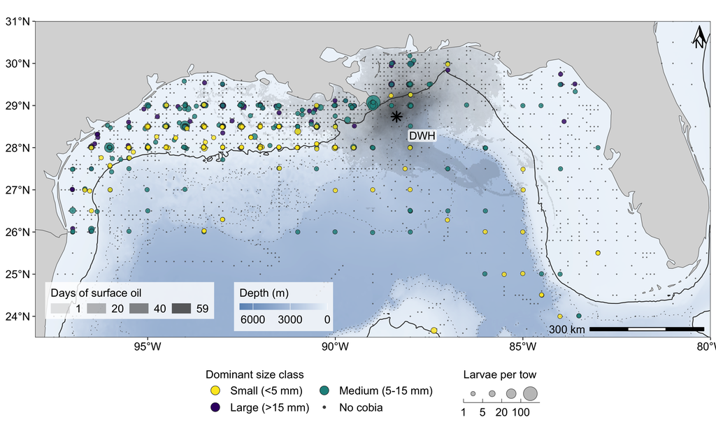

```r
oil_file <- file.path(dir_derived, "dwh_days_oiling_2km.tif")
if (!file.exists(oil_file)) {
  oil_raw <- rast("data/raw/dwh_oiling/All_SARDays_020515/AllSAR_0205.tif")
  levels(oil_raw) <- NULL
  oil_agg <- aggregate(oil_raw, fact = 40, fun = "max", na.rm = TRUE)
  oil_agg[oil_agg == 0] <- NA
  writeRaster(oil_agg, oil_file, overwrite = TRUE)
}
oil <- as.data.frame(rast(oil_file), xy = TRUE) %>% set_names(c("lon", "lat", "days"))
# Cell maxima overstate the oiled area, so no area is quoted from this layer.

# Depth is the blue fill. Oil is drawn over it in gray, darker with more days of oiling.
p_oil <- ggplot() +
  geom_raster(data = bathy, aes(lon, lat, fill = z), interpolate = TRUE) +
  scale_fill_gradient(low = "#6A93BF", high = "#EEF4FA", name = "Depth (m)",
                      labels = function(x) -x, breaks = c(0, -3000, -6000),
                      guide = guide_colourbar(order = 4, position = "inside", direction = "horizontal",
                                              barwidth = unit(80, "pt"), barheight = unit(6, "pt"),
                                              theme = theme(legend.title.position = "top"))) +
  geom_raster(data = oil, aes(lon, lat, alpha = days), fill = "grey10") +
  scale_alpha_continuous(range = c(0.12, 0.7), limits = c(1, 59), breaks = c(1, 20, 40, 59),
                         name = "Days of surface oil",
                         guide = guide_legend(order = 3, position = "inside", nrow = 1, direction = "horizontal",
                                              override.aes = list(fill = "grey10"),
                                              theme = theme(legend.title.position = "top"))) +
  geom_sf(data = filter(iso, depth_m == 200), colour = "grey20", linewidth = 0.35) +
  geom_sf(data = filter(iso, depth_m > 200), colour = "grey35", linewidth = 0.2,
          linetype = "dotted") +
  geom_sf(data = land, fill = "grey85", colour = "grey40", linewidth = 0.2) +
  ggnewscale::new_scale_fill() +
  geom_point(data = no_cobia, aes(lon, lat, fill = "No cobia"), size = 0.6, alpha = 0.75,
             shape = 21, stroke = 0) +
  geom_point(data = DWH, aes(lon, lat), shape = 8, size = 2.6, stroke = 0.9) +
  annotate("label", x = DWH$lon + 0.3, y = DWH$lat - 0.45, label = "DWH", size = FONT_PT / .pt,
           family = SANS, fontface = FONT_FACE, hjust = 0, fill = alpha("white", 0.75),
           border.colour = NA, label.padding = unit(1.2, "pt")) +
  geom_point(data = gulf %>% filter(!is.na(size_class)) %>%
               arrange(desc(as.integer(size_class)), desc(n_total)),
             aes(lon, lat, size = n_total, fill = size_class), shape = 21, colour = "grey15",
             stroke = 0.3, alpha = 0.8) +
  scale_fill_manual(values = c(SIZE_COLS, "No cobia" = "grey30"), name = "Dominant size class",
                    breaks = c(SIZE_LEVELS, "No cobia"), drop = FALSE) +
  scale_size_binned(breaks = c(1, 5, 20, 100), range = c(1.2, 6.5), name = "Larvae per tow",
                    nice.breaks = FALSE) +
  guides(fill = guide_legend(order = 1, nrow = 2, byrow = TRUE,
                             override.aes = list(size = c(3.6, 3.6, 3.6, 1.4), alpha = 1,
                                                 colour = c(rep("grey15", 3), NA))),
         size = guide_bins(order = 2, override.aes = list(shape = 21, fill = "grey70",
                                                          colour = "grey15", stroke = 0.3))) +
  map_frame +
  # depth and oil scales sit in the empty deep basin; point legends go in one row underneath
  theme(panel.background = element_rect(fill = "#EEF4FA"), legend.box = "horizontal",
        legend.box.just = "top", legend.spacing.x = unit(18, "pt"),
        legend.title.position = "top",
        legend.key = element_rect(fill = NA, colour = NA),
        legend.position.inside = c(0.015, 0.02), legend.justification.inside = c(0, 0),
        legend.box.background = element_blank(),
        legend.background = element_rect(fill = alpha("white", 0.8), colour = NA))
p_oil
```

# Season

Shelf stations from 1982 to 2016 only, so every month covers the same area and years.

```r
recs <- rates  %>% filter(sta_depth_m > 0, sta_depth_m <= SHELF_M, year %in% SERIES)
eff  <- effort %>% filter(sta_depth_m > 0, sta_depth_m <= SHELF_M, year %in% SERIES)
cpue <- recs %>% count(month, wt = n_total, name = "n_larvae") %>%
  complete(month = 1:12, fill = list(n_larvae = 0)) %>%
  left_join(eff %>% count(month, name = "n_tows"), by = "month") %>%
  mutate(per_100 = if_else(n_tows > 0, 100 * n_larvae / n_tows, NA_real_),
         month_lab = factor(month.abb[month], levels = month.abb))
write_csv(cpue, file.path(dir_derived, "cpue_by_month.csv"), na = "")
cpue %>% select(month_lab, n_larvae, n_tows, per_100)
```

| month_lab | n_larvae | n_tows | per_100 |
| --- | --- | --- | --- |
| Jan | 0 | 194 | 0.0000000 |
| Feb | 0 | 477 | 0.0000000 |
| Mar | 0 | 575 | 0.0000000 |
| Apr | 0 | 297 | 0.0000000 |
| May | 48 | 1266 | 3.7914692 |
| Jun | 591 | 2191 | 26.9739845 |
| Jul | 316 | 1899 | 16.6403370 |
| Aug | 42 | 970 | 4.3298969 |
| Sep | 247 | 5950 | 4.1512605 |
| Oct | 5 | 2201 | 0.2271695 |
| Nov | 0 | 1583 | 0.0000000 |
| Dec | 0 | 312 | 0.0000000 |

The same rates for the Texas–Louisiana shelf alone, which was sampled in every month.

```r
tx <- effort %>% filter(region == "Texas-Louisiana shelf", year %in% SERIES) %>%
  count(month, name = "tows") %>%
  left_join(rates %>% filter(region == "Texas-Louisiana shelf", year %in% SERIES) %>%
              count(month, wt = n_total, name = "larvae"), by = "month") %>%
  mutate(rate = round(100 * coalesce(larvae, 0) / tows, 1))
tx %>% filter(month %in% c(5:9)) %>% select(month, tows, larvae, rate)
```

| month | tows | larvae | rate |
| --- | --- | --- | --- |
| 5 | 841 | 47 | 5.6 |
| 6 | 1744 | 572 | 32.8 |
| 7 | 1568 | 303 | 19.3 |
| 8 | 747 | 42 | 5.6 |
| 9 | 3094 | 240 | 7.8 |

Each bar is split by the size composition of the larvae measured in that month.

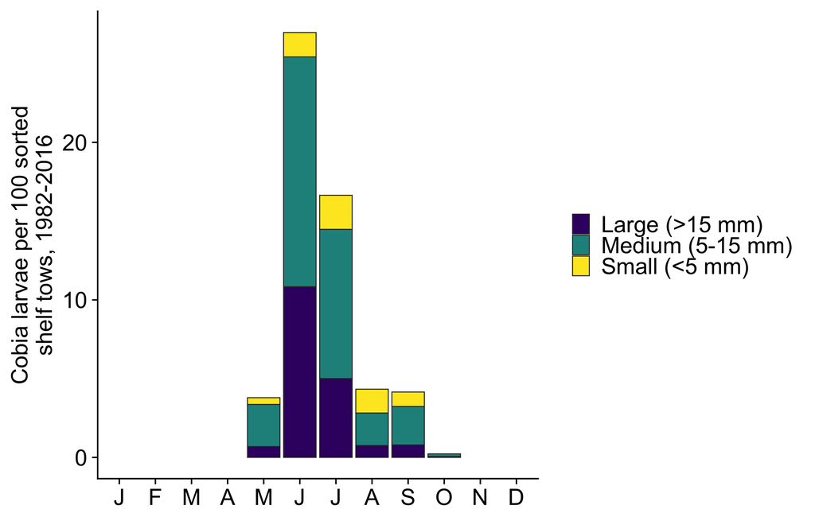

```r
mix <- lengths %>% inner_join(select(recs, v_c_p_s_cat, month), by = "v_c_p_s_cat") %>%
  count(month, size, name = "n_meas") %>%
  group_by(month) %>% mutate(share = n_meas / sum(n_meas)) %>% ungroup()

p_season <- cpue %>% select(month, month_lab, per_100) %>% inner_join(mix, by = "month") %>%
  ggplot(aes(month_lab, per_100 * share, fill = size)) +
  geom_col(colour = "grey20", linewidth = 0.2) +
  scale_fill_manual(values = SIZE_COLS, name = NULL, drop = FALSE,
                    guide = guide_legend(reverse = TRUE)) +
  scale_x_discrete(labels = substr(month.abb, 1, 1), drop = FALSE) +
  theme(legend.position = "right", legend.key.size = unit(8, "pt"),
        legend.text = element_text(size = FONT_PT)) +
  labs(x = NULL, y = "Cobia larvae per 100 sorted\nshelf tows, 1982-2016")
p_season
```

# Shelf comparison

June and July only, because the two shelves differ in when they were sampled.

```r
peak_eff  <- effort %>% filter(month %in% PEAK)
peak_recs <- rates  %>% filter(month %in% PEAK)
CELL <- 0.5
cell <- function(x) mutate(x, cx = floor(lon / CELL) * CELL + CELL / 2,
                              cy = floor(lat / CELL) * CELL + CELL / 2)
cells <- cell(peak_eff) %>% count(cx, cy, name = "n_tows") %>%
  left_join(cell(peak_recs) %>% group_by(cx, cy) %>%
              summarise(n_larvae = sum(n_total), .groups = "drop"), by = c("cx", "cy")) %>%
  mutate(n_larvae = coalesce(n_larvae, 0), per_100 = 100 * n_larvae / n_tows,
         searched = n_tows >= 10)
sprintf("cells with >=10 June-July tows: %d; of those with no cobia: %d",
        sum(cells$searched), sum(cells$searched & cells$n_larvae == 0))
```

```
[1] "cells with >=10 June-July tows: 109; of those with no cobia: 43"
```

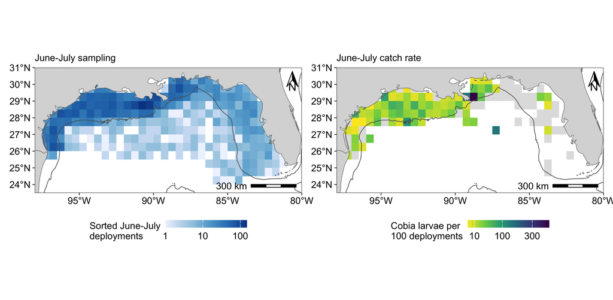

```r
frame <- list(geom_sf(data = filter(iso, depth_m == 200), colour = "grey35", linewidth = 0.3),
              geom_sf(data = land, fill = "grey85", colour = "grey40", linewidth = 0.2),
              map_frame, theme(panel.background = element_rect(fill = "white")),
              theme(plot.title = element_text(size = FONT_PT, face = FONT_FACE)))
p_eff <- ggplot() + geom_tile(data = cells, aes(cx, cy, fill = n_tows)) +
  scale_fill_distiller(trans = "log10", palette = "Blues", direction = 1,
                       name = "Sorted June-July\ndeployments", breaks = c(1, 10, 100)) +
  frame + ggtitle("June-July sampling")
p_rate <- ggplot() +
  geom_tile(data = filter(cells, searched, n_larvae == 0), aes(cx, cy), fill = "grey88") +
  geom_tile(data = filter(cells, n_larvae > 0), aes(cx, cy, fill = per_100)) +
  scale_fill_viridis_c(trans = "sqrt", option = "viridis", direction = -1,
                       name = "Cobia larvae per\n100 deployments", breaks = c(10, 100, 300)) +
  frame + ggtitle("June-July catch rate")
p_eff | p_rate
```

Larvae are matched to effort by station and gear. Confidence intervals resample tows with replacement 2,000 times.

```r
tow_catch <- peak_recs %>% filter(year %in% SERIES) %>%
  mutate(gear_class = if_else(gear == "Neuston", "Neuston", "Bongo")) %>%
  group_by(v_c_p, gear_class) %>% summarise(n = sum(n_total), .groups = "drop")
set.seed(7)
boot_ci <- function(x, n = 2000) quantile(replicate(n, 100 * mean(sample(x, replace = TRUE))),
                                          c(0.025, 0.975))
reg <- peak_eff %>% filter(!is.na(region), year %in% SERIES) %>%
  select(v_c_p, gear, region) %>%
  left_join(tow_catch, by = c("v_c_p", "gear" = "gear_class")) %>%
  mutate(n = coalesce(n, 0)) %>%
  group_by(region) %>%
  summarise(tows = n(), larvae = sum(n), rate = 100 * mean(n), pct_tows_with = 100 * mean(n > 0),
            ci = list(boot_ci(n)), .groups = "drop") %>%
  mutate(lo = map_dbl(ci, 1), hi = map_dbl(ci, 2), .keep = "unused")   # both limits from one set of resamples
write_csv(reg, file.path(dir_derived, "shelf_comparison.csv"))
reg
```

| region | tows | larvae | rate | pct_tows_with | lo | hi |
| --- | --- | --- | --- | --- | --- | --- |
| Texas-Louisiana shelf | 3312 | 875 | 26.419082 | 6.642512 | 16.032609 | 42.844958 |
| West Florida shelf | 725 | 31 | 4.275862 | 1.517241 | 1.241379 | 9.103448 |

Station depth, gear mix, and years sampled on the two shelves.

```r
peak_eff %>% filter(!is.na(region), year %in% SERIES) %>%
  group_by(region) %>%
  summarise(years = n_distinct(year), depth_med = round(median(sta_depth_m)),
            depth_q1 = round(quantile(sta_depth_m, .25)),
            depth_q3 = round(quantile(sta_depth_m, .75)),
            pct_bongo = round(100 * mean(gear == "Bongo")), .groups = "drop")
```

| region | years | depth_med | depth_q1 | depth_q3 | pct_bongo |
| --- | --- | --- | --- | --- | --- |
| Texas-Louisiana shelf | 35 | 31 | 18 | 49 | 52 |
| West Florida shelf | 27 | 35 | 24 | 59 | 53 |

# Size

```r
by_depth <- lengths %>%
  inner_join(select(gulf, v_c_p_s_cat, sta_depth_m, month), by = "v_c_p_s_cat") %>%
  filter(sta_depth_m > 0)
by_depth %>% mutate(where = if_else(sta_depth_m <= SHELF_M, "shelf", "off-shelf")) %>%
  group_by(where) %>% summarise(n = n(), median_mm = median(length_mm),
                                median_depth_m = round(median(sta_depth_m)))
```

| where | n | median_mm | median_depth_m |
| --- | --- | --- | --- |
| off-shelf | 117 | 6.7 | 969 |
| shelf | 867 | 10.0 | 44 |

```r
by_depth %>% filter(month %in% 4:10) %>% count(month, size) %>%
  group_by(month) %>% mutate(pct = round(100 * n / sum(n))) %>%
  select(-n) %>% pivot_wider(names_from = size, values_from = pct)
```

| month | Small (<5 mm) | Medium (5-15 mm) | Large (>15 mm) |
| --- | --- | --- | --- |
| 4 | 93 | 7 | NA |
| 5 | 31 | 64 | 5 |
| 6 | 6 | 56 | 39 |
| 7 | 13 | 57 | 30 |
| 8 | 34 | 51 | 15 |
| 9 | 27 | 57 | 16 |
| 10 | NA | 75 | 25 |

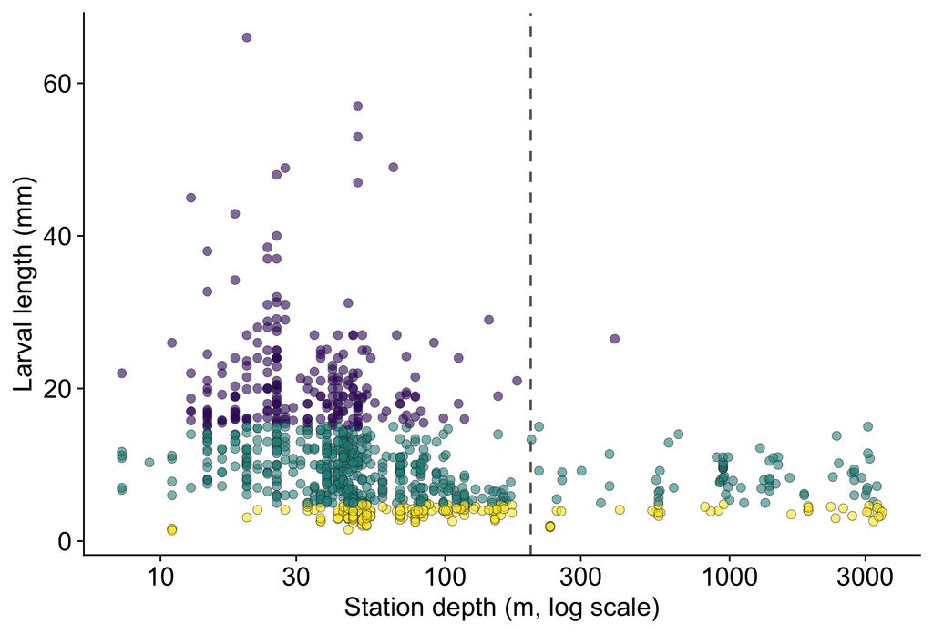

```r
p_size <- ggplot(by_depth, aes(sta_depth_m, length_mm, fill = size)) +
  geom_point(shape = 21, colour = "grey20", stroke = 0.2, alpha = 0.6, size = 1.5) +
  scale_fill_manual(values = SIZE_COLS, guide = "none") +
  scale_x_log10(breaks = c(10, 30, 100, 300, 1000, 3000)) +
  geom_vline(xintercept = SHELF_M, linetype = "dashed", colour = "grey40") +
  labs(x = "Station depth (m, log scale)", y = "Larval length (mm)")
p_size
```

The share of small larvae caught on the shelf, across several size cut-offs.

```r
map_dfr(c(3, 3.2, 3.5, 4, 4.5, 5), function(cut) {
  keep <- lengths %>% group_by(v_c_p_s_cat) %>%
    summarise(hit = any(length_mm <= cut), .groups = "drop") %>% filter(hit)
  g <- gulf %>% filter(v_c_p_s_cat %in% keep$v_c_p_s_cat, !is.na(sta_depth_m))
  tibble(cut_mm = cut, larvae = sum(lengths$length_mm <= cut), records = nrow(g),
         pct_shelf = round(100 * mean(g$sta_depth_m <= SHELF_M)))
})
```

| cut_mm | larvae | records | pct_shelf |
| --- | --- | --- | --- |
| 3.0 | 47 | 24 | 88 |
| 3.2 | 55 | 30 | 87 |
| 3.5 | 75 | 41 | 80 |
| 4.0 | 126 | 81 | 75 |
| 4.5 | 170 | 116 | 78 |
| 5.0 | 225 | 151 | 79 |

# Day and night

Day and night rates by gear and size class.

```r
diel <- lengths %>%
  inner_join(rates %>% filter(!is.na(night)) %>% select(v_c_p_s_cat, gear, night),
             by = "v_c_p_s_cat") %>%
  count(gear, night, size, name = "larvae") %>%
  left_join(effort %>% filter(!is.na(night)) %>% count(gear, night, name = "tows"),
            by = c("gear", "night")) %>%
  mutate(per_100 = 100 * larvae / tows) %>%
  select(gear, size, night, per_100) %>%
  pivot_wider(names_from = night, values_from = per_100, names_prefix = "n") %>%
  transmute(gear, size, day = round(nFALSE, 2), night = round(nTRUE, 2),
            ratio = round(nTRUE / nFALSE, 2)) %>% arrange(gear, size)
write_csv(diel, file.path(dir_derived, "diel_by_gear_size.csv"))
diel
```

| gear | size | day | night | ratio |
| --- | --- | --- | --- | --- |
| Bongo | Small (<5 mm) | 0.53 | 0.55 | 1.03 |
| Bongo | Medium (5-15 mm) | 0.33 | 0.35 | 1.07 |
| Bongo | Large (>15 mm) | 0.01 | 0.05 | 3.63 |
| Neuston | Small (<5 mm) | 0.11 | 1.05 | 9.77 |
| Neuston | Medium (5-15 mm) | 0.78 | 6.11 | 7.84 |
| Neuston | Large (>15 mm) | 0.73 | 2.37 | 3.24 |

The bongo values for large larvae are based on four larvae.

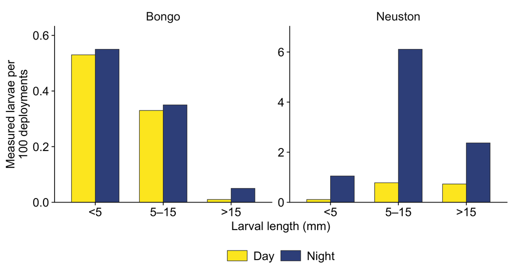

```r
p_diel <- diel %>% pivot_longer(c(day, night), names_to = "tod", values_to = "per_100") %>%
  ggplot(aes(size, per_100, fill = tod)) +
  geom_col(position = "dodge", colour = "grey20", linewidth = 0.2, width = 0.7) +
  facet_wrap(~ gear, scales = "free_y") +
  scale_fill_manual(values = c(day = "#FDE725", night = "#3B528B"), name = NULL,
                    labels = c(day = "Day", night = "Night")) +
  scale_x_discrete(labels = c("<5", "5\u201315", ">15")) +
  scale_y_continuous(expand = expansion(mult = c(0, 0.15))) +   # room for the panel letters
  labs(x = "Larval length (mm)", y = "Measured larvae per\n100 deployments")
p_diel
```

June and July shelf rates by day and night, before and after the mid-1990s change to night sampling on the trawl surveys.

```r
era <- effort %>% filter(!is.na(night), month %in% PEAK, sta_depth_m > 0,
                           sta_depth_m <= SHELF_M, year %in% SERIES) %>%
  mutate(era = if_else(year < 1995, "1982-1994", "1995-2016")) %>%
  count(era, night, name = "tows") %>%
  left_join(rates %>% filter(!is.na(night), month %in% PEAK, sta_depth_m > 0,
                               sta_depth_m <= SHELF_M, year %in% SERIES) %>%
              mutate(era = if_else(year < 1995, "1982-1994", "1995-2016")) %>%
              count(era, night, wt = n_total, name = "larvae"), by = c("era", "night")) %>%
  mutate(larvae = coalesce(larvae, 0), per_100 = round(100 * larvae / tows, 1))
write_csv(era, file.path(dir_derived, "diel_by_era.csv"))
era
```

| era | night | tows | larvae | per_100 |
| --- | --- | --- | --- | --- |
| 1982-1994 | FALSE | 1199 | 17 | 1.4 |
| 1982-1994 | TRUE | 335 | 54 | 16.1 |
| 1995-2016 | FALSE | 1591 | 120 | 7.5 |
| 1995-2016 | TRUE | 965 | 716 | 74.2 |

# Temperature and salinity

Surface temperature at capture against the temperature of all tows, following Ditty and Shaw (1992).

```r
temp_tows <- effort %>% filter(!is.na(temp_surf))
temp_pos  <- rates %>% filter(!is.na(temp_surf)) %>% uncount(n_total)

bind_rows(
  tibble(set = "All sorted tows",   t = temp_tows$temp_surf),
  tibble(set = "Larvae",            t = temp_pos$temp_surf)) %>%
  group_by(set) %>%
  summarise(n = n(), mean = round(mean(t), 1), median = round(median(t), 1),
            min = round(min(t), 1), max = round(max(t), 1),
            pct_25_30 = round(100 * mean(t >= 25 & t <= 30), 1), .groups = "drop")
```

| set | n | mean | median | min | max | pct_25_30 |
| --- | --- | --- | --- | --- | --- | --- |
| All sorted tows | 28288 | 26.9 | 27.4 | 10.9 | 34.8 | 69.1 |
| Larvae | 1401 | 29.0 | 29.3 | 23.0 | 32.5 | 84.4 |

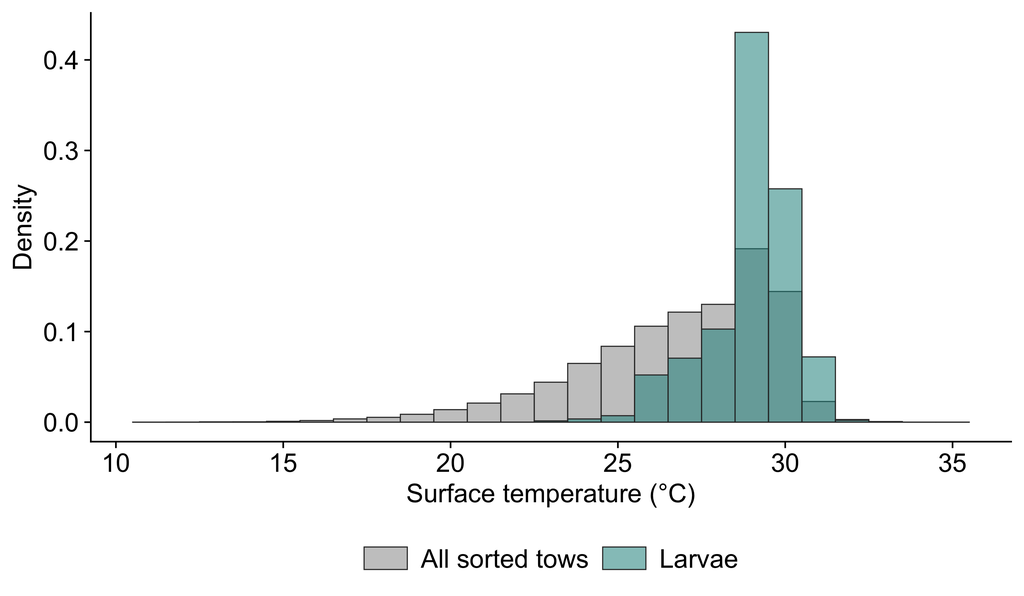

```r
p_temp <- bind_rows(
  tibble(set = "All sorted tows", t = temp_tows$temp_surf),
  tibble(set = "Larvae",          t = temp_pos$temp_surf)) %>%
  ggplot(aes(t, after_stat(density), fill = set)) +
  geom_histogram(binwidth = 1, position = "identity", alpha = 0.55,
                 colour = "grey20", linewidth = 0.2) +
  scale_fill_manual(values = c("All sorted tows" = "grey60", "Larvae" = "#21908C"), name = NULL) +
  labs(x = "Surface temperature (°C)", y = "Density")
p_temp
```

Surface salinity the same way, and again within June and July on each shelf.

```r
sal_tows <- effort %>% filter(!is.na(sal_surf))
sal_pos  <- rates %>% filter(!is.na(sal_surf)) %>% uncount(n_total)

bind_rows(
  tibble(set = "All sorted tows",   s = sal_tows$sal_surf),
  tibble(set = "Larvae",            s = sal_pos$sal_surf)) %>%
  group_by(set) %>%
  summarise(n = n(), mean = round(mean(s), 1), median = round(median(s), 1),
            min = round(min(s), 1), max = round(max(s), 1), .groups = "drop")
```

| set | n | mean | median | min | max |
| --- | --- | --- | --- | --- | --- |
| All sorted tows | 26835 | 33.9 | 35.5 | 6.0 | 38.1 |
| Larvae | 1389 | 31.0 | 31.4 | 10.4 | 36.8 |

```r
# Within June and July on each shelf, 1982-2016: larvae against the tows around them
sal_region <- bind_rows(
  effort %>% filter(month %in% PEAK, sta_depth_m > 0, sta_depth_m <= SHELF_M, year %in% SERIES,
                    !is.na(region), !is.na(sal_surf)) %>%
    group_by(region) %>% summarise(set = "Tows", n = n(), mean = round(mean(sal_surf), 1),
                                   median = round(median(sal_surf), 1), .groups = "drop"),
  rates %>% filter(month %in% PEAK, sta_depth_m > 0, sta_depth_m <= SHELF_M, year %in% SERIES,
                   !is.na(region), !is.na(sal_surf)) %>%
    uncount(n_total) %>%
    group_by(region) %>% summarise(set = "Larvae", n = n(), mean = round(mean(sal_surf), 1),
                                   median = round(median(sal_surf), 1), .groups = "drop")) %>%
  arrange(region, desc(set))
write_csv(sal_region, file.path(dir_derived, "salinity_by_region.csv"))
sal_region
```

| region | set | n | mean | median |
| --- | --- | --- | --- | --- |
| Texas-Louisiana shelf | Tows | 3097 | 29.8 | 31.0 |
| Texas-Louisiana shelf | Larvae | 863 | 29.5 | 29.6 |
| West Florida shelf | Tows | 652 | 34.2 | 35.3 |
| West Florida shelf | Larvae | 31 | 33.5 | 34.8 |

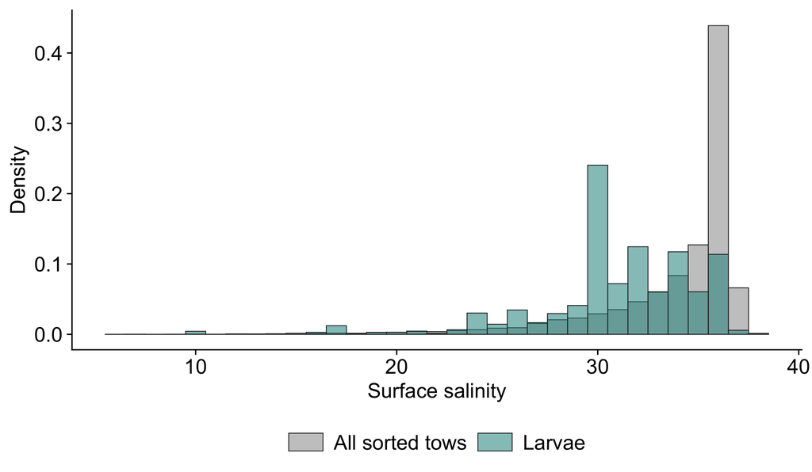

```r
p_sal <- bind_rows(
  tibble(set = "All sorted tows", s = sal_tows$sal_surf),
  tibble(set = "Larvae",          s = sal_pos$sal_surf)) %>%
  ggplot(aes(s, after_stat(density), fill = set)) +
  geom_histogram(binwidth = 1, position = "identity", alpha = 0.55,
                 colour = "grey20", linewidth = 0.2) +
  scale_fill_manual(values = c("All sorted tows" = "grey60", "Larvae" = "#21908C"), name = NULL) +
  labs(x = "Surface salinity", y = "Density")
p_sal
```

# Journal figures

```r
dir_journal <- file.path(dir_fig, "journal")
dir.create(dir_journal, showWarnings = FALSE)
# The macOS PDF device embeds system fonts (Arial, Times New Roman); the CRAN build's cairo_pdf
# does not find them there. Elsewhere cairo_pdf does.
pdf_device <- if (capabilities("aqua")) {
  function(filename, width, height, bg = "white", ...)
    grDevices::quartz(type = "pdf", file = filename, width = width, height = height, bg = bg)
} else grDevices::cairo_pdf
save_fig <- function(p, name, w, h) {
  ggsave(file.path(dir_journal, paste0(name, ".pdf")), p, width = w, height = h,
         device = pdf_device)
  ggsave(file.path(dir_journal, paste0(name, ".tif")), p, width = w, height = h, dpi = 600,
         device = ragg::agg_tiff, compression = "lzw")
}
diel_letters <- tibble(gear = c("Bongo", "Neuston"), lab = c("A", "B"))

save_fig(p_oil + theme(plot.margin = margin(2, 20, 2, 2)),
         "fig1_distribution", 7, 4.6)
save_fig(p_season, "fig2_season", 5, 2.6)
save_fig((p_eff + panel_letter("A")) / (p_rate + panel_letter("B")), "fig3_june_july_maps", 7, 7.6)
save_fig(p_size, "fig4_size_depth", 3.5, 2.8)
save_fig(p_diel + geom_label(data = diel_letters, aes(x = -Inf, y = Inf, label = lab),
                             inherit.aes = FALSE, hjust = -0.25, vjust = 1.25, family = SERIF,
                             fontface = "bold", size = TAG_PT / .pt, fill = "white",
                             label.size = 0) +
           theme(strip.text = element_text(hjust = 0.5)),
         "fig5_day_night", 7, 3)
save_fig((p_temp + panel_letter("A")) / (p_sal + panel_letter("B")) +
           plot_layout(guides = "collect") & theme(legend.position = "bottom"),
         "fig6_temperature_salinity", 3.5, 5.4)
```

# Numbers for the text

## Catch by gear

All standard deployments, 1982-2024.

```r
all_tows <- effort %>% select(v_c_p, gear, night) %>%
  left_join(rates %>% group_by(v_c_p, gear) %>% summarise(n = sum(n_total), .groups = "drop"),
            by = c("v_c_p", "gear")) %>%
  mutate(n = coalesce(n, 0))
all_tows %>% group_by(gear) %>%
  summarise(tows = n(), larvae = sum(n), per_100 = round(100 * mean(n), 2),
            pct_tows_with = round(100 * mean(n > 0), 2), .groups = "drop") %>%
  mutate(pct_of_larvae = round(100 * larvae / sum(larvae), 1))
```

| gear | tows | larvae | per_100 | pct_tows_with | pct_of_larvae |
| --- | --- | --- | --- | --- | --- |
| Bongo | 13991 | 131 | 0.94 | 0.66 | 9.1 |
| Neuston | 15272 | 1301 | 8.52 | 2.66 | 90.9 |

```r
all_tows %>% filter(!is.na(night)) %>%
  group_by(gear, night) %>% summarise(tows = n(), per_100 = round(100 * mean(n), 1), .groups = "drop")
```

| gear | night | tows | per_100 |
| --- | --- | --- | --- |
| Bongo | FALSE | 7664 | 0.9 |
| Bongo | TRUE | 6327 | 1.0 |
| Neuston | FALSE | 8345 | 2.0 |
| Neuston | TRUE | 6927 | 16.4 |

```r
sprintf("deployments with cobia: %d of %d", sum(all_tows$n > 0), nrow(all_tows))
```

```
[1] "deployments with cobia: 498 of 29263"
```

```r
# Larvae per record, all records in the study area
gulf %>% summarise(records = n(), median_larvae = median(n_total),
                   pct_one_or_two = round(100 * mean(n_total <= 2)))
```

| records | median_larvae | pct_one_or_two |
| --- | --- | --- |
| 547 | 1 | 79 |

```r
# Larvae left out of every rate, by reason
gulf %>%
  mutate(why = if_else(gear %in% c("Bongo", "Neuston"), "in the rates", paste("gear:", gear))) %>%
  count(why, wt = n_total, name = "larvae")
```

| why | larvae |
| --- | --- |
| gear: Bongo (non-standard) | 19 |
| gear: Bongo (second net) | 2 |
| gear: MOCNESS | 23 |
| gear: Neuston (non-standard) | 17 |
| gear: Neuston (second net) | 6 |
| in the rates | 1432 |

## Monthly day and night

Shelf rates by month for day and night tows, 1982-2016.

```r
effort %>% filter(!is.na(night), sta_depth_m > 0, sta_depth_m <= SHELF_M, year %in% SERIES) %>%
  count(month, night, name = "tows") %>%
  left_join(rates %>% filter(!is.na(night), sta_depth_m > 0, sta_depth_m <= SHELF_M,
                             year %in% SERIES) %>%
              count(month, night, wt = n_total, name = "larvae"), by = c("month", "night")) %>%
  mutate(larvae = coalesce(larvae, 0), per_100 = round(100 * larvae / tows, 1)) %>%
  filter(month %in% 5:9)
```

| month | night | tows | larvae | per_100 |
| --- | --- | --- | --- | --- |
| 5 | FALSE | 662 | 6 | 0.9 |
| 5 | TRUE | 604 | 42 | 7.0 |
| 6 | FALSE | 1485 | 56 | 3.8 |
| 6 | TRUE | 706 | 535 | 75.8 |
| 7 | FALSE | 1305 | 81 | 6.2 |
| 7 | TRUE | 594 | 235 | 39.6 |
| 8 | FALSE | 493 | 10 | 2.0 |
| 8 | TRUE | 477 | 32 | 6.7 |
| 9 | FALSE | 3169 | 26 | 0.8 |
| 9 | TRUE | 2781 | 221 | 7.9 |

## Survey shares and coverage

```r
# Larvae by station depth, all records in the study area
gulf %>% filter(!is.na(sta_depth_m)) %>%
  summarise(pct_under_100_m = round(100 * sum(n_total[sta_depth_m < 100]) / sum(n_total), 1),
            pct_shelf_200_m = round(100 * sum(n_total[sta_depth_m <= SHELF_M]) / sum(n_total), 1),
            beyond_shelf_larvae = sum(n_total[sta_depth_m > SHELF_M]),
            beyond_shelf_records = sum(sta_depth_m > SHELF_M))
```

| pct_under_100_m | pct_shelf_200_m | beyond_shelf_larvae | beyond_shelf_records |
| --- | --- | --- | --- |
| 84.7 | 90.6 | 141 | 83 |

```r
# Deployments by survey group, all and shelf only
shelf <- effort %>% filter(sta_depth_m > 0, sta_depth_m <= SHELF_M)
tibble(plankton_surveys_pct_all = round(100 * mean(effort$survey %in% c("Fall plankton", "Spring plankton")), 1),
       trawl_surveys_pct_all    = round(100 * mean(effort$survey %in% c("Summer trawl", "Fall trawl")), 1),
       trawl_surveys_pct_shelf  = round(100 * mean(shelf$survey %in% c("Summer trawl", "Fall trawl")), 1))
```

| plankton_surveys_pct_all | trawl_surveys_pct_all | trawl_surveys_pct_shelf |
| --- | --- | --- |
| 63.3 | 23.7 | 34.7 |

```r
# June and July West Florida shelf deployments, 1982-2016, by survey
effort %>% filter(month %in% PEAK, year %in% SERIES, region == "West Florida shelf") %>% count(survey)
```

| survey | n |
| --- | --- |
| Spring plankton | 29 |
| Summer trawl | 690 |
| Other | 6 |

```r
# Years the summer trawl survey reached the West Florida shelf (east of 88 W)
effort %>% filter(survey == "Summer trawl", lon >= -88) %>% count(year, name = "deployments")
```

| year | deployments |
| --- | --- |
| 1982 | 85 |
| 1983 | 56 |
| 1984 | 20 |
| 1985 | 75 |
| 1986 | 6 |
| 1987 | 16 |
| 1988 | 4 |
| 1989 | 10 |
| 1994 | 4 |
| 1996 | 4 |
| 1997 | 2 |
| 2000 | 2 |
| 2001 | 2 |
| 2002 | 4 |
| 2003 | 4 |
| 2006 | 2 |
| 2007 | 2 |
| 2009 | 9 |
| 2011 | 4 |
| 2012 | 126 |
| 2013 | 113 |
| 2014 | 93 |
| 2015 | 92 |
| 2016 | 38 |

```r
# Share of each shelf's tows in June and July, which is why the shelves are compared in those months
effort %>% filter(!is.na(region), sta_depth_m <= SHELF_M) %>%
  group_by(region) %>%
  summarise(shelf_tows = n(), pct_in_june_july = round(100 * mean(month %in% PEAK)), .groups = "drop")
```

| region | shelf_tows | pct_in_june_july |
| --- | --- | --- |
| Texas-Louisiana shelf | 12646 | 26 |
| West Florida shelf | 6163 | 12 |

```r
# June and July shelf tows by year since 2013; none after 2016
effort %>% filter(month %in% PEAK, sta_depth_m > 0, sta_depth_m <= SHELF_M, year >= 2013) %>%
  count(year, name = "june_july_shelf_tows")
```

| year | june_july_shelf_tows |
| --- | --- |
| 2013 | 203 |
| 2014 | 260 |
| 2015 | 189 |
| 2016 | 127 |

```r
# November to March shelf deployments, 1982-2016, by survey
shelf %>% filter(month %in% c(11, 12, 1, 2, 3), year %in% SERIES) %>% count(survey) %>%
  bind_rows(tibble(survey = "Total", n = sum(.$n)))
```

| survey | n |
| --- | --- |
| Fall trawl | 1284 |
| Winter | 1483 |
| Other | 374 |
| Total | 3141 |

```r
# Temperature and salinity coverage: deployments, and larvae in the rates
tibble(temp_pct_deployments = round(100 * mean(!is.na(effort$temp_surf)), 1),
       sal_pct_deployments  = round(100 * mean(!is.na(effort$sal_surf)), 1),
       temp_larvae = sum(rates$n_total[!is.na(rates$temp_surf)]),
       sal_larvae  = sum(rates$n_total[!is.na(rates$sal_surf)]))
```

| temp_pct_deployments | sal_pct_deployments | temp_larvae | sal_larvae |
| --- | --- | --- | --- |
| 96.7 | 91.7 | 1401 | 1389 |

## Ditty and Shaw comparison

Shares of all larvae in the study area, as Ditty and Shaw (1992) reported them.

```r
gulf %>% summarise(
  larvae = sum(n_total),
  pct_may_sep = round(100 * sum(n_total[month %in% 5:9]) / larvae, 1),
  pct_jun_sep = round(100 * sum(n_total[month %in% 6:9]) / larvae, 1),
  pct_under_100m = round(100 * sum(n_total[sta_depth_m < 100]) / larvae, 1),
  median_depth_m = round(median(rep(sta_depth_m, n_total))),
  records_off_shelf = sum(sta_depth_m > SHELF_M),
  larvae_off_shelf = sum(n_total[sta_depth_m > SHELF_M]))
```

| larvae | pct_may_sep | pct_jun_sep | pct_under_100m | median_depth_m | records_off_shelf | larvae_off_shelf |
| --- | --- | --- | --- | --- | --- | --- |
| 1499 | 98.5 | 85.7 | 84.7 | 42 | 83 | 141 |

```r
count(gulf, month, wt = n_total, name = "larvae")
```

| month | larvae |
| --- | --- |
| 4 | 17 |
| 5 | 191 |
| 6 | 613 |
| 7 | 317 |
| 8 | 49 |
| 9 | 306 |
| 10 | 5 |
| 12 | 1 |

## Sensitivity checks

The shelf comparison without the two largest catches, for 1995-2016 only, by time of day, and by gear, with intervals that resample whole cruises.

```r
shelf_tows <- peak_eff %>% filter(!is.na(region), year %in% SERIES) %>%
  select(v_c_p, gear, region, year, night) %>%
  left_join(tow_catch, by = c("v_c_p", "gear" = "gear_class")) %>%
  mutate(n = coalesce(n, 0), cruise = substr(v_c_p, 1, 5))   # vessel + cruise number

shelf_rate <- function(d, case) d %>% group_by(region) %>%
  summarise(rate = 100 * mean(n), .groups = "drop") %>%
  pivot_wider(names_from = region, values_from = rate) %>%
  transmute(case, tx_la = round(`Texas-Louisiana shelf`, 1), w_fl = round(`West Florida shelf`, 1),
            ratio = round(`Texas-Louisiana shelf` / `West Florida shelf`, 1))   # from unrounded rates
bind_rows(
  shelf_rate(shelf_tows, "all"),
  shelf_rate(filter(shelf_tows, rank(-n, ties.method = "first") > 2), "without the 2 largest catches"),
  shelf_rate(filter(shelf_tows, year >= 1995), "1995-2016"),
  shelf_rate(filter(shelf_tows, night %in% FALSE), "day"),
  shelf_rate(filter(shelf_tows, night %in% TRUE), "night"),
  shelf_rate(filter(shelf_tows, gear == "Neuston"), "neuston"),
  shelf_rate(filter(shelf_tows, gear == "Bongo"), "bongo"))
```

| case | tx_la | w_fl | ratio |
| --- | --- | --- | --- |
| all | 26.4 | 4.3 | 6.2 |
| without the 2 largest catches | 18.3 | 4.3 | 4.3 |
| 1995-2016 | 39.5 | 6.0 | 6.5 |
| day | 5.8 | 0.5 | 12.2 |
| night | 76.4 | 9.6 | 8.0 |
| neuston | 52.5 | 8.8 | 6.0 |
| bongo | 2.2 | 0.3 | 8.3 |

```r
set.seed(7)
shelf_tows %>% group_by(region) %>%
  summarise(cruises = n_distinct(cruise), pct_night = round(100 * mean(night, na.rm = TRUE)),
            ci = list(quantile(replicate(2000, {
              by_cruise <- split(n, cruise)
              100 * mean(unlist(by_cruise[sample(names(by_cruise), replace = TRUE)]))
            }), c(0.025, 0.975))), .groups = "drop") %>%
  mutate(lo = round(map_dbl(ci, 1), 1), hi = round(map_dbl(ci, 2), 1), .keep = "unused")
```

| region | cruises | pct_night | lo | hi |
| --- | --- | --- | --- | --- |
| Texas-Louisiana shelf | 107 | 29 | 13.8 | 45.0 |
| West Florida shelf | 46 | 42 | 0.9 | 10.1 |